# Modeling Insurance Claims Frequency and Severity

### 4.2.3 Enriched Features

After including our continuous binned variables, we will now add the new geospatial and enriched features:

- `REGION_merged`
- `MUNICIPALITY_binned`
- `POPULATION_binned`

Because the bins in `MUNICIPALITY_binned` are very small, they will not do well with cross-validation, so we will focus on the other two enriched features and then test the impact of including `MUNICIPALITY_binned` without cross-validation.

```r
f_enr2 <- paste0(base_f, " + REGION_merged + POPULATION_binned")
cat(sprintf("> Formula after adding two enriched features: %s", f_enr2))
```

```
> Formula after adding two enriched features: NCLAIMS ~ offset(log(EXP)) + COVERAGE + FUEL + FLEET + SEX + BM_binned + AGEPH_binned_merged + AGEC_binned + POWER_binned_merged + REGION_merged + POPULATION_binned
```

```r
r_enr2 <- create_wflow_freq_glm(train_data, f_enr2)
perf_metrics_df <- append_performance_metrics(name = "Enriched Features", formula = f_enr2, result = r_enr2)
test_enr2 <- anova(base_mod$fit, r_enr2$fit, test = "Chisq")
cat(sprintf("Are we gaining significant explanatory power by adding enriched features? %s (p-value = %.4f)\n", ifelse(test_enr2$`Pr(>Chi)`[2] < 0.05, "Yes", "No"), test_enr2$`Pr(>Chi)`[2]))
```

```
Are we gaining significant explanatory power by adding enriched features? Yes (p-value = 0.0000)
```

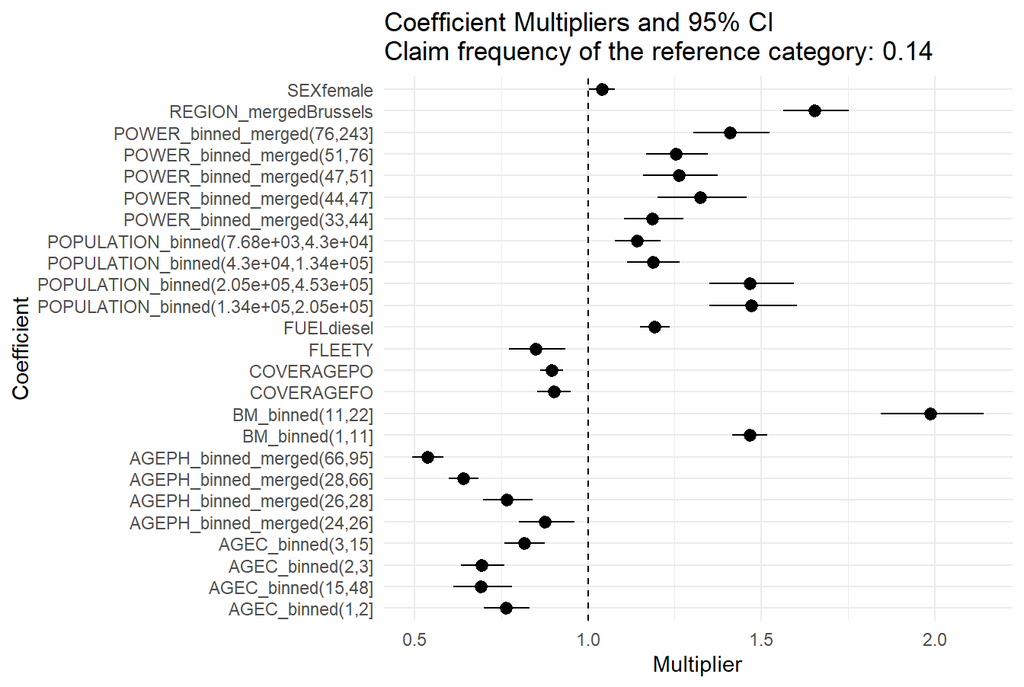

```r
coefs_enr2 <- check_summary(r_enr2)
plot_summary(r_enr2)
```

We notice that the `REGION_merged` and `POPULATION_binned` variables contribute significantly to the model, it was therefore worth including them as enriched features in our final model.

- `REGION_mergedBrussels` is actually the second highest multiplier of claim frequency in the model: 1.6540695 (95% CI: 1.5623668 - 1.7511546)
- The two largest bins in `POPULATION_binned` have significant but similar coefficients, we will also consider merging them in the final model section.

Finally, let’s have a quick look at the `MUNICIPALITY_binned` variable to see if it can add anything to the urban and population density we already considered. Note that we won’t use our workflow because the bins are too small and we will run into issues with non-observed levels in the cross-validation folds. We’ll make a single GLM fit to test our hypothesis.

```r
f_enr3 <- paste0(f_enr2, " + MUNICIPALITY_binned")
cat(sprintf("> Formula after adding MUNICIPALITY_binned: %s", f_enr3))
```

```
> Formula after adding MUNICIPALITY_binned: NCLAIMS ~ offset(log(EXP)) + COVERAGE + FUEL + FLEET + SEX + BM_binned + AGEPH_binned_merged + AGEC_binned + POWER_binned_merged + REGION_merged + POPULATION_binned + MUNICIPALITY_binned
```

```r
r_enr3 <- list()
r_enr3$fit <- glm(as.formula(f_enr3), data = train_data, family = poisson())
test_enr3 <- anova(r_enr2$fit, r_enr3$fit, test = "Chisq")
cat(sprintf("Does MUNICIPALITY_binned add significant explanatory power? %s (p-value = %.4f)\n", ifelse(test_enr3$`Pr(>Chi)`[2] < 0.05, "Yes", "No"), test_enr3$`Pr(>Chi)`[2]))
```

```
Does MUNICIPALITY_binned add significant explanatory power? Yes (p-value = 0.0309)
```

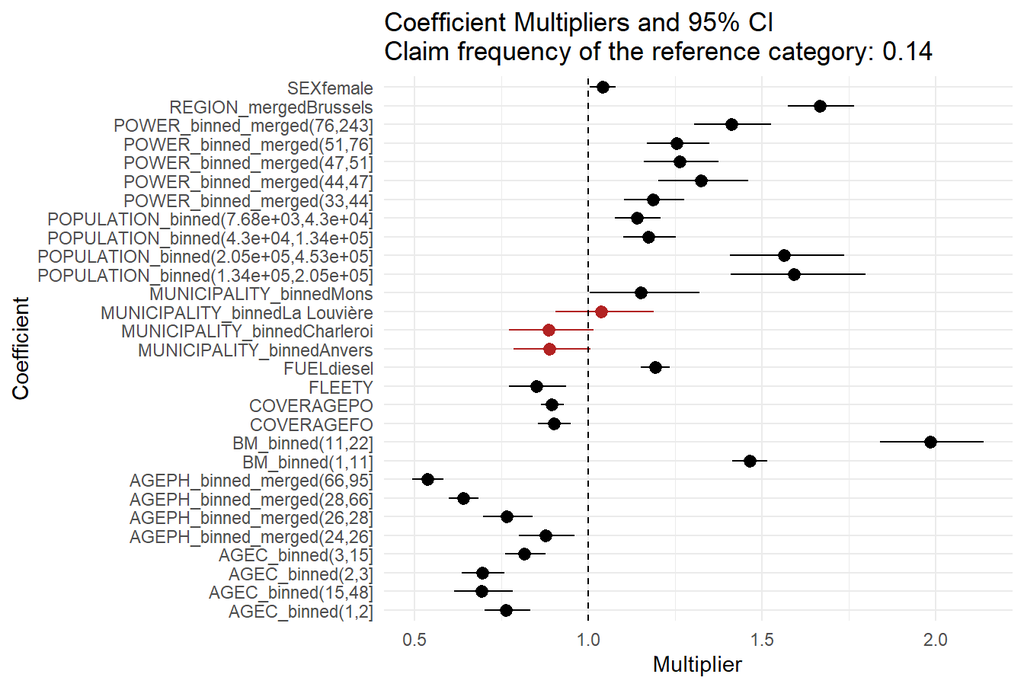

```r
coefs_enr3 <- check_summary(r_enr3)
plot_summary(r_enr3)
```

```r
# base_mod <- r_enr2$fit
```

The interpretation of the `MUNICIPALITY_binned` effect on the model is difficult. We first see that the effet of La Louvière, Charleroi, and Anvers are not significant. Only Mons is significant but barely. What is more interesting to notice is that we only have four out of the six original municipalities. This is because of `collinearity`. As we explained in the feature engineering section, adding similar views of the geographical location yields redundant information and the model automatically drops some levels to avoid perfect multicollinearity. We can dive deeper in this issue with the `alias` function in R, which shows which coefficients are linearly dependent and therefore dropped from the model.

```r
alias_mat <- alias(r_enr3$fit)$Complete
alias_mat[, colSums(abs(alias_mat)) > 0] %>% kable(
    caption = "Alias matrix for MUNICIPALITY_binned"
)
```

Alias matrix for MUNICIPALITY_binned

|  | POPULATION_binned(1.34e+05,2.05e+05] | POPULATION_binned(2.05e+05,4.53e+05] | MUNICIPALITY_binnedCharleroi | MUNICIPALITY_binnedAnvers |
| --- | --- | --- | --- | --- |
| MUNICIPALITY_binnedGand | 0 | 1 | 0 | -1 |
| MUNICIPALITY_binnedLiège | 1 | 0 | -1 | 0 |

```r
train_data %>%
  filter(POPULATION_binned == "(2.05e+05,4.53e+05]", MUNICIPALITY_binned != "Anvers") %>%
  select(MUNICIPALITY_binned) %>%
  unique() %>%
  kable(
    caption = "MUNICIPALITY_binned values for the filtered criteria"
  )
```

MUNICIPALITY_binned values for the filtered criteria

| MUNICIPALITY_binned |
| --- |
| Gand |

Even if adding the `MUNICIPALITY_binned` variable to the model adds some explanatory power, it creates multicollinearity issues and provides a single, barely interpretable coefficient for Mons. We will therefore not include the `MUNICIPALITY_binned` variable in our best model and continue with only the two other features.

```r
base_f <- f_enr2
base_mod <- r_enr2
```

### 4.2.4 Interaction Effects

The final complexity layer for this GLM estimation chapter for the claim frequency model is to include the interaction effects we identified with the decision tree analysis.

The interaction based on expert knowledge will also be considered:

Because interactions will create very small cross sections, we’ll skip cross validation and use a single GLM estimation.

```r
f_int <- paste0(base_f, " + ", paste(interaction_features, collapse = " + "))
cat(sprintf("> Formula after adding specific interaction: %s", f_int))
```

[output not shown]

```r
r_int <- list()
r_int$fit <- glm(as.formula(f_int), data = train_data, family = poisson())
test_int <- anova(base_mod$fit, r_int$fit, test = "Chisq")
cat(sprintf("Are we gaining significant explanatory power by adding interactions? %s (p-value = %.4f)\n", ifelse(test_int$`Pr(>Chi)`[2] < 0.05, "Yes", "No"), test_int$`Pr(>Chi)`[2]))
```

```
Are we gaining significant explanatory power by adding interactions? Yes (p-value = 0.0000)
```

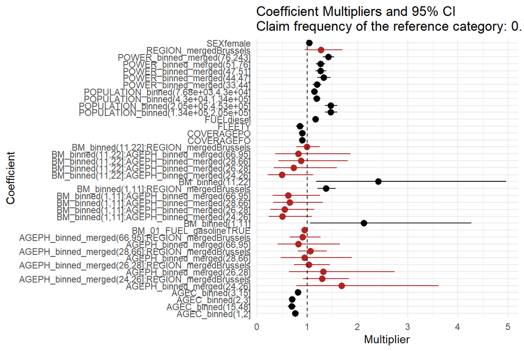

```r
coefs_int <- check_summary(r_int)
plot_summary(r_int)
```

Note that even if the interactions add some explanatory power, they make the model more complex, less stable, and harder to interpret. The region Brussels for example does not have a significant effect anymore as it is included in the interaction terms and confounded with other variables. Besides, only the specific BM between 1 and 11 x Brussels Region has a significant effect on claim frequency. We can focus on the two specific interactions only to see if we can have a more interpretable and stable model.

```r
f_sp_int <- paste0(base_f, " + BM_01_FUEL_not_gasoline + BM_01_FUEL_gasoline")
cat(sprintf("> Formula after adding specific interaction: %s", f_sp_int))
```

```
> Formula after adding specific interaction: NCLAIMS ~ offset(log(EXP)) + COVERAGE + FUEL + FLEET + SEX + BM_binned + AGEPH_binned_merged + AGEC_binned + POWER_binned_merged + REGION_merged + POPULATION_binned + BM_01_FUEL_not_gasoline + BM_01_FUEL_gasoline
```

```r
r_sp_int <- list()
r_sp_int$fit <- glm(as.formula(f_sp_int), data = train_data, family = poisson())
test_sp_int <- anova(base_mod$fit, r_sp_int$fit, test = "Chisq")
cat(sprintf("Are we gaining significant explanatory power by adding interactions? %s (p-value = %.4f)\n", ifelse(test_sp_int$`Pr(>Chi)`[2] < 0.05, "Yes", "No"), test_sp_int$`Pr(>Chi)`[2]))
```

```
Are we gaining significant explanatory power by adding interactions? No (p-value = 0.0548)
```

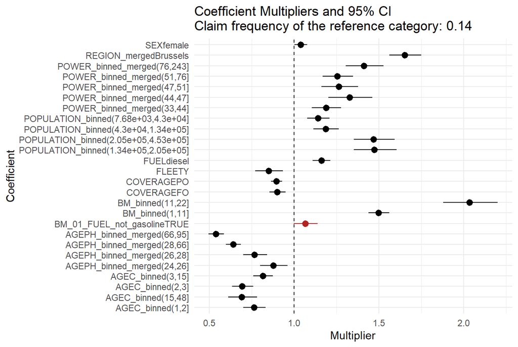

```r
coefs_sp_int <- check_summary(r_sp_int)
plot_summary(r_sp_int)
```

The `BM_01_FUEL_gasoline` = True is a linear combination of other covariates that are present in the model and is excluded due to perfect multicollinearity. The other specific interaction `BM_01_FUEL_not_gasoline` = True is not significant. We will therefore not include these specific interactions either. Based on this complexity layer approach, we can select the enriched model as our best model as far. In the last part of this GLM modeling, we will summarize the performance metrics and prune the best model for similar coefficients.

### 4.2.5 Selection of the Best Model

We can close the GLM frequency model estimation here by looking at the evolution of our performance metrics across the different modeling stages:

```r
perf_metrics_df %>% arrange(CV_Prediction_Error) %>% select(-Formula) %>% kable(
    booktabs = TRUE, caption = "Final Leaderboard ordered by CV Prediction Error"
)
```

Final Leaderboard ordered by CV Prediction Error

| Model | AIC | BIC | Deviance | CV_Deviance | CV_Complexity | CV_Prediction_Error | CV_LogLoss |
| --- | --- | --- | --- | --- | --- | --- | --- |
| Enriched Features | 99575.66 | 99829.94 | 69479.20 | 69552.74 | 52 | 69604.74 | 0.3813501 |
| All Continuous Binned | 99985.22 | 100190.59 | 69898.75 | 69954.12 | 42 | 69996.12 | 0.3828870 |
| Continuous Binned without SEX | 99988.13 | 100183.73 | 69903.66 | 69957.85 | 40 | 69997.85 | 0.3829012 |
| Categorical Only | 101514.34 | 101573.02 | 71457.87 | 71469.36 | 12 | 71481.36 | 0.3886887 |
| Intercept Only | 101738.48 | 101748.26 | 71692.01 | 71694.04 | 2 | 71696.04 | 0.3895490 |

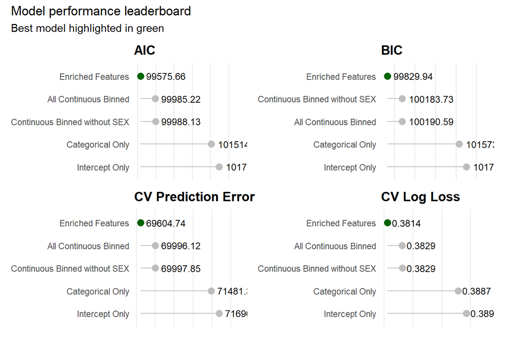

```r
plot_leaderboard <- function(data, metric, title, digits = 2) {

    plot_data <- data %>%
        transmute(
            Model = as.character(Model),
            value = .data[[metric]]
        ) %>%
        arrange(desc(value)) %>%
        mutate(
            Model = factor(Model, levels = Model),
            best = value == min(value, na.rm = TRUE)
        )

    ggplot(plot_data, aes(x = value, y = Model)) +
        geom_segment(
            aes(x = min(value), xend = value, yend = Model),
            colour = "grey75"
        ) +
        geom_point(aes(colour = best), size = 3) +
        geom_text(
            aes(label = formatC(value, format = "f", digits = digits)),
            hjust = -0.15,
            size = 3.3
        ) +
        scale_colour_manual(
            values = c("FALSE" = "grey", "TRUE" = "darkgreen"),
            guide = "none"
        ) +
        scale_x_continuous(
            expand = expansion(mult = c(0.08, 0.35))
        ) +
        labs(title = title, x = NULL, y = NULL) +
        # remove x-axis labels
        theme_minimal(base_size = 11) +
        theme(
            panel.grid.major.y = element_blank(),
            panel.grid.minor = element_blank(),
            plot.title = element_text(face = "bold"),
            axis.text.x = element_blank()
        )
}

p1 <- plot_leaderboard(perf_metrics_df, "AIC", "AIC")
p2 <- plot_leaderboard(perf_metrics_df, "BIC", "BIC")
p3 <- plot_leaderboard(perf_metrics_df, "CV_Prediction_Error", "CV Prediction Error")
p4 <- plot_leaderboard(
    perf_metrics_df, "CV_LogLoss", "CV Log Loss", digits = 4
)

(p1 | p2) / (p3 | p4) +
    plot_annotation(
        title = "Model performance leaderboard",
        subtitle = "Best model highlighted in green"
)
```

Based on this leaderboard, we can confirm that our final model with categorical, significant binned continuous features and significant enriched features performs the best across all evaluated metrics. The other models have the same ranking across AIC, cross-validated prediction error, and cross-validated Poisson log loss. The only difference we noticed is in the BIC metric that penalizes more model complexity. The penalisation coefficient is sufficiently large to prefer the model with continuous bins without sex to the one with sex included.

Now that we have identified the best-performing model, can we proceed to merge levels with similar effects without losing predictive power?

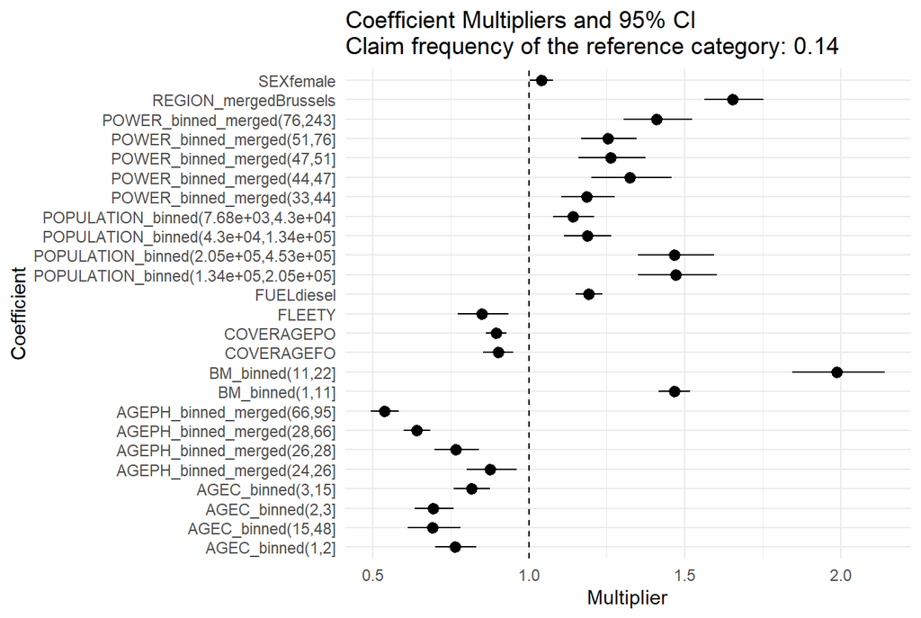

```r
plot_summary(base_mod)
```

Visual inspection points towards the following potential merges:

1. `POPULATION_binned`: (1.34e+05,2.05e+05] and (2.05e+05,4.53e+05]
2. `COVERAGE`: PO and FO under OM for omnium
3. `POWER_binned`: (47-51] and (51-76]

We will adapt the recipe in our workflow to implement these potential merges and evaluate their impact on model performance one by one.

```r
rec_pop <- recipe(NCLAIMS ~ ., data = train_data) %>%
    step_mutate(
        POPULATION_binned = fct_collapse(POPULATION_binned,
            "(1.34e+05,4.53e+05]" = c("(1.34e+05,2.05e+05]", "(2.05e+05,4.53e+05]")
        )
    )
r_mpop <- create_wflow_freq_glm(train_data, base_f, rec = rec_pop)
perf_metrics_df <- append_performance_metrics(name = "Merged POPULATION_binned", formula = base_f, result = r_mpop)
test_mpop <- anova(base_mod$fit, r_mpop$fit, test = "Chisq")
cat(sprintf("Are we gaining significant explanatory power by keeping the levels separate? %s (p-value = %.4f)\n", ifelse(test_mpop$`Pr(>Chi)`[2] < 0.05, "Yes", "No"), test_mpop$`Pr(>Chi)`[2]))
```

```
Are we gaining significant explanatory power by keeping the levels separate? No (p-value = 0.9508)
```

Merging the `POPULATION_binned` levels (1.34e+05,2.05e+05] and (2.05e+05,4.53e+05] into a single level (1.34e+05,4.53e+05] allows us to simplify the model without losing significant explanatory power, as indicated by the p-value from the likelihood ratio test. Let’s proceed with the coverage variable. We already identified in the data exploration that the `PO` and `FO` could potentially be merged under the `OM` level for omnium coverage.

```r
base_mod <- r_mpop
rec_cov <- rec_pop %>%
    step_mutate(
        COVERAGE = fct_collapse(COVERAGE,
            "OM" = c("PO", "FO")
        )
    )
r_mcov <- create_wflow_freq_glm(train_data, base_f, rec = rec_cov)
perf_metrics_df <- append_performance_metrics(name = "Merged COVERAGE", formula = base_f, result = r_mcov)
test_mcov <- anova(base_mod$fit, r_mcov$fit, test = "Chisq")
cat(sprintf("Are we gaining significant explanatory power by keeping the COVERAGE levels separate? %s (p-value = %.4f)\n", ifelse(test_mcov$`Pr(>Chi)`[2] < 0.05, "Yes", "No"), test_mcov$`Pr(>Chi)`[2]))
```

```
Are we gaining significant explanatory power by keeping the COVERAGE levels separate? No (p-value = 0.8404)
```

Again, merging the `COVERAGE` levels `PO` and `FO` into a single `OM` level simplifies the model without a significant loss of explanatory power, as indicated by the p-value from the likelihood ratio test. Let’s continue with our third and last potential merge for the `POWER_binned` variable.

```r
base_mod <- r_mcov
rec_pow <- rec_cov %>%
    step_mutate(
        POWER_binned_merged = fct_collapse(POWER_binned_merged,
            "(47,76]" = c("(47,51]","(51,76]")
        )
    )
r_mpow <- create_wflow_freq_glm(train_data, base_f, rec = rec_pow)
perf_metrics_df <- append_performance_metrics(name = "Merged POWER_binned", formula = base_f, result = r_mpow)
test_mpow <- anova(base_mod$fit, r_mpow$fit, test = "Chisq")
cat(sprintf("Are we gaining significant explanatory power by keeping the POWER_binned levels separate? %s (p-value = %.4f)\n", ifelse(test_mpow$`Pr(>Chi)`[2] < 0.05, "Yes", "No"), test_mpow$`Pr(>Chi)`[2]))
```

```
Are we gaining significant explanatory power by keeping the POWER_binned levels separate? No (p-value = 0.8127)
```

It seems that all merges make sense. Let’s visualize the performance and coefficients of our final best GLM model.

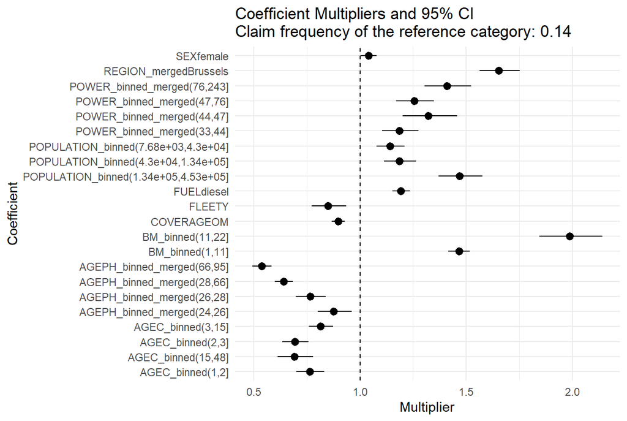

```r
base_mod <- r_mpow
base_rec <- rec_pow

plot_summary(base_mod)
```

```r
perf_metrics_df %>% arrange(CV_Prediction_Error) %>% select(-Formula) %>% kable(
    booktabs = TRUE, caption = "Final Leaderboard after levels merging ordered by CV Prediction Error"
)
```

Final Leaderboard after levels merging ordered by CV Prediction Error

| Model | AIC | BIC | Deviance | CV_Deviance | CV_Complexity | CV_Prediction_Error | CV_LogLoss |
| --- | --- | --- | --- | --- | --- | --- | --- |
| Merged POWER_binned | 99569.76 | 99794.70 | 69479.30 | 69548.24 | 46 | 69594.24 | 0.3813329 |
| Merged COVERAGE | 99571.71 | 99806.42 | 69479.24 | 69548.75 | 48 | 69596.75 | 0.3813348 |
| Merged POPULATION_binned | 99573.67 | 99818.16 | 69479.20 | 69550.47 | 50 | 69600.47 | 0.3813414 |
| Enriched Features | 99575.66 | 99829.94 | 69479.20 | 69552.74 | 52 | 69604.74 | 0.3813501 |
| All Continuous Binned | 99985.22 | 100190.59 | 69898.75 | 69954.12 | 42 | 69996.12 | 0.3828870 |
| Continuous Binned without SEX | 99988.13 | 100183.73 | 69903.66 | 69957.85 | 40 | 69997.85 | 0.3829012 |
| Categorical Only | 101514.34 | 101573.02 | 71457.87 | 71469.36 | 12 | 71481.36 | 0.3886887 |
| Intercept Only | 101738.48 | 101748.26 | 71692.01 | 71694.04 | 2 | 71696.04 | 0.3895490 |

Our final best GLM model is the simplified one with merged `COVERAGE`, `POWER_binned` and `POPULATION_levels`. The CV Complexity obviously favors this simplified model, but even the cross-validated deviance and log loss are slightly better which indicates that the model generalizes better. We will take this model as the base for our subsequent GAM exploration.

## 4.3 Frequency GAM Workflow

With our best GLM model as basis, we will explore whether incorporating smoothed terms for continuous variables instead of using bins can improve model performance.

### 4.3.1 Smoothing Example for Spatial Effect

To illustrate the power of smoothing, we will compare the coefficients and significance of `LONG` in `LAT` when used in a GLM versus a GAM. Note that in the GAM[^16], we will use the bivariate smooth term `s(LONG, LAT)` to capture the spatial effect and not the tensor product smooth `te(LONG, LAT)` becayse the two variables have the same units (isotropic).

```r
glm_long_lat <- glm(NCLAIMS ~ offset(log(EXP)) + LONG + LAT, data = train_data, family = poisson())
summary(glm_long_lat)$coefficients %>% kable(
    booktabs = TRUE, caption = "GLM Coefficients for LONG and LAT"
)
```

GLM Coefficients for LONG and LAT

|  | Estimate | Std. Error | z value | Pr(>\|z\|) |
| --- | --- | --- | --- | --- |
| (Intercept) | -6.6979190 | 1.3208076 | -5.071078 | 0.0000004 |
| LONG | 0.0203941 | 0.0108303 | 1.883059 | 0.0596924 |
| LAT | 0.0912505 | 0.0257542 | 3.543135 | 0.0003954 |

```r
cl <- makeCluster(detectCores() - 1)
bam_freq_long_lat <- bam(NCLAIMS ~ offset(log(EXP)) + s(LONG, LAT), data = train_data, family = poisson(), cluster = cl)
stopCluster(cl)
summary(bam_freq_long_lat)$s.table %>%
    kable(
        booktabs = TRUE,
        caption = "Approximate significance of spatial smooth"
    )
```

Approximate significance of spatial smooth

|  | edf | Ref.df | Chi.sq | p-value |
| --- | --- | --- | --- | --- |
| s(LONG,LAT) | 23.91589 | 27.33209 | 329.7599 | 0 |

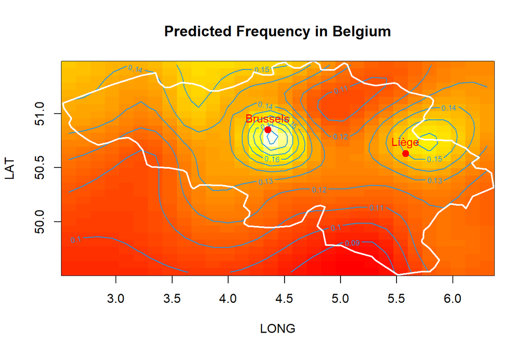

```r
vis.gam(
    bam_freq_long_lat, view = c("LONG", "LAT"), plot.type = "contour", type="response",
    main = "Predicted Frequency in Belgium", cond = list(EXP = 1)
)
maps::map("world", regions = "Belgium", add = TRUE, col = "white", lwd = 2)
points(
    x = c(4.3517, 5.5797),
    y = c(50.8503, 50.6326),
    col = "red", pch = 19, cex = 1.2
)
text(
    x = c(4.3517, 5.5797),
    y = c(50.8503, 50.6326),
    labels = c("Brussels", "Liège"),
    pos = 3, col = "red", cex = 0.9
)
```

From a statistical perspective, the GAM yields a far more significant predictor with the spatial smooth term `s(LONG, LAT)` compared to the individual coefficients for `LONG` (not even significant) and `LAT` in the GLM. But more importantly, the non-linear spatial effect can be visualized and interpreted, showing for example that frequency is a lot higher around Brussels (as we see with the `REGION` variable in the GLM) and close to Liège. It is also lower in rural parts of the country namely in the Ardennes and other sparsely populated areas.

```r
## The Spatial Effect for Severity are non-significant, this might be due to the small number of claims

# cl <- makeCluster(detectCores() - 1)
# bam_sev_long_lat_avg <- bam(
#     AVG ~ s(LONG, LAT), data = train_data, family = Gamma(link = "log"),
#     subset = NCLAIMS > 0, weights = NCLAIMS,
#     cluster = cl
# )
# bam_sev_long_lat_amount <- bam(
#     AMOUNT ~ offset(NCLAIMS) + s(LONG, LAT), data = train_data, family = Gamma(link = "log"),
#     subset = NCLAIMS > 0, weights = NCLAIMS,
#     cluster = cl
# )
# stopCluster(cl)

# vis.gam(
#     bam_sev_long_lat_avg, view = c("LONG", "LAT"), plot.type = "contour", type="response",
#     main = "Predicted Severity in Belgium", cond = list(EXP = 1)
# )
# map("world", regions = "Belgium", add = TRUE, col = "white", lwd = 2)
# points(
#     x = c(4.3517, 5.5797),
#     y = c(50.8503, 50.6326),
#     col = "red", pch = 19, cex = 1.2
# )
# text(
#     x = c(4.3517, 5.5797),
#     y = c(50.8503, 50.6326),
#     labels = c("Brussels", "Liège"),
#     pos = 3, col = "red", cex = 0.9
# )
```

### 4.3.3 Model Fitting, Pruning, and Comparison

Fit the candidate GAMs, assess the contribution of their terms, and compare their performance using the frequency validation framework.

### 4.3.4 Smooth Effects Compared with Bins and Polynomial Transformations

Visualize the smooth functions and compare their shapes with the binned numerical effects and the raw and orthogonal polynomial explorations.

## 4.4 Final Frequency Model

### 4.4.1 Holdout Evaluation and Technical Model Selection

Compare the shortlisted GLM and GAM predictions on the holdout set to assess the final technical model choice.

### 4.4.2 Merging Levels with Similar Effects

### 4.4.3 Removing Sensitive Variables

### 4.4.4 Commercial Model Coefficient Interpretation

# 5 Severity Modeling

We went through a lot of details in the data preparation and model selection process for the frequency component of our analysis. For the severity component, we will go through a similar process in much lesser depth to keep this report concise. We will nevertheless go through the following steps:

- Filter out non-relevant observations for the severity analysis
- Look at the distribution of the severity across individual features
- Adapt the validation metrics to the Gamma family with a log link
- Compare claim-count weighting of average costs with a claim-count offset for total costs
- Fit, prune, and compare successive GLM layers using cross-validation
- Evaluate the shortlisted models on the holdout set, then simplify and interpret the final model

Watch out that we are not using the canonical link function for the Gamma distribution, which is the inverse link. This means that the sum of predicted values might not equal the total observed cost. In a real-world setting, we would need to account for this discrepancy when setting premiums. The reason why we will use the log link instead of the canonical inverse link is to ensure that our predicted values are always positive and to simplify the interpretation of the model coefficients (as multiplicative effects on the expected value of the response variable).

## 5.1 Validation Framework

### 5.1.1 Data Preparation for Severity Analysis

```r
train_severity <- train_data[train_data$NCLAIMS > 0, ]
avg_cost_int <- glm(AVG ~ 1, data = train_severity, family = Gamma(link = "log"))
avg_cost_int_sum <- summary(avg_cost_int)
beta <- avg_cost_int_sum$coefficients[1, 1]
beta_sd <- avg_cost_int_sum$coefficients[1, 2]
cat(sprintf("Estimated mean of average cost: %.2f (95%% CI: %.2f to %.2f)", exp(beta), exp(beta - 1.96 * beta_sd), exp(beta + 1.96 * beta_sd)))
```

```
Estimated mean of average cost: 1698.68 (95% CI: 1418.70 to 2033.92)
```

```r
mean_avg <- mean(train_severity$AVG)
sd_avg <- sd(train_severity$AVG)
cat(sprintf("Observed mean of average cost: %.2f (sd-based 95%% CI: %.2f to %.2f)", mean_avg, mean_avg - 1.96 * sd_avg, mean_avg + 1.96 * sd_avg))
```

```
Observed mean of average cost: 1698.68 (sd-based 95% CI: -35232.05 to 38629.42)
```

### 5.1.2 Gamma Performance Metrics and Cross-Validation

Adapt the frequency validation framework to positive claim costs, using Gamma deviance and negative log-likelihood with a consistent treatment of claim-count weights. Apply the same preparation pipeline within each cross-validation fold and reserve the holdout set for final evaluation.

## 5.2 Generalized Linear Models (GLM) - Gamma(log)

### 5.2.1 Average Claim Cost Weights and Total Claim Cost Offset

Compare modeling average claim cost with the number of claims as weights against modeling total claim cost with the log number of claims as an offset. Check the corresponding Gamma dispersion and likelihood specifications when assessing their equivalence.

### 5.2.2 Categorical Variables Only

### 5.2.3 Adding Binned Numerical Variables

### 5.2.4 Adding Enriched Features

### 5.2.5 Adding Interactions

### 5.2.6 Cross-Validated Performance Summary and GLM Model Selection

Compare the fitted and pruned models from each complexity layer using the severity validation metrics.

## 5.3 Final Severity Model

### 5.3.1 Holdout Evaluation and Technical Model Selection

### 5.3.2 Merging Levels with Similar Effects

### 5.3.3 Removing Sensitive Variables

### 5.3.4 Commercial Model Coefficient Interpretation

# 6 Premium Modeling

## 6.1 Combined Model

### 6.1.1 Combining Frequency and Severity Predictions

Combine the expected claim frequency and expected claim severity to obtain the expected claim cost for each policy, accounting for the exposure basis of the frequency predictions.

### 6.1.2 Severity Intercept Rescaling for Observation-Prediction Alignment

Assess aggregate observed and predicted claim costs, then rescale the severity intercept to align their totals on the calibration data. Keep the holdout set separate from this calibration.

## 6.2 Interpretation

### 6.2.1 Combined Coefficients and Feature Effects

Interpret how the frequency and severity effects combine in the premium structure, distinguishing coefficient-based multiplicative effects from any retained GAM smooth effects.

### 6.2.2 Premium Predictions by Policyholder Class

Present the resulting premium predictions for representative policyholder classes.

# 7 Conclusion